# Homework #1

Ryan Lode

This homework is more or less a tutorial that helps you set up the coding environment used in this course, and familiarizes you with the format of the assignment submission. As a pre-requisite of this homework, first install R, and then the RStudio (the free version of Rstudio Desktop).

1. Create a folder named `ds202_hw1`, and **either** create an RMarkDown file `hw1.Rmd` under this folder **or** move the provided template into this folder. `hw1.Rmd` will include your solutions. The file and folder names are *case-sensitive*, which means `hw1.Rmd` and `HW1.rmd` are different. *It is crucial to follow the exact folder structure and file names* in this course, so that your homework can be reproduced. The correct folder structure is

   ```
   ds202_hw1
   |-- hw1.Rmd
   |-- hw1.html (generated after knitting)
   ```

   Answer: Done
2. Write your name in the YAML of your homework `Rmd` file.

   Answer: Done
3. Write a paragraph to introduce yourself. Set your name in bold font and your major in italic.

   Answer:

   My name is **Ryan Lode** and I am a *Data Science* Major.This will be my second full-time semester at Iowa State and I never imagined I’d be taking classes under these circumstances.However, I’m excited to learn and begin exploring data. I live in Ankeny with my wife and two dogs. My hobbies include reading, board games, and playing Dungeons and Dragons. My favorite genera of music is **Metal** and it’s pretty much all I listen to.
4. Write a paragraph describing a job that you think is related to data science. Include a hyperlink and an image. Make sure your answer is in a nice format to read.

   Answer:

   While there are a million and one ways to apply data science, I found an interesting example used by wildlife biologists at the Nature Conservancy in Massachusetts. They recently used graduate students to build an algorithm which sifts through trail camera images to find photos of animals, even in situations where the animal is heavily obscured. A person going through the photos on their own would take days to identify the relevant pictures, but the program was able to complete the task with 97 percent accuracy in minutes.

   https://www.nature.org/en-us/about-us/where-we-work/united-states/massachusetts/stories-in-massachusetts/data-science-wildlife-photos/

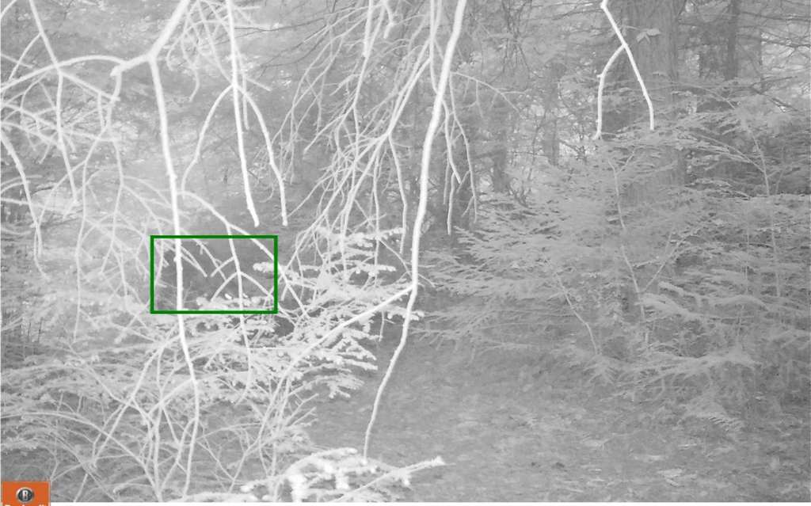

5. What data topic will you be most interested in? (Optional) Provide a source of such dataset if you have.

   Answer:

   Sticking with the theme, I’ll say conservation data, but there are a variety of topics I’m interested in exploring. Here is a dataset showing the  
   biodiversity present at various national parks:

   https://www.kaggle.com/nationalparkservice/park-biodiversity
6. To check that your R and Rstudio installation is correct, find the version of R by entering `version` into the R console. Include this command into a R code trunk in your solution `Rmd` file to have it automatically printed in the knitted html file.

   Answer:

   ```r
   version
   ```

   ```
   ##                _
   ## platform       x86_64-w64-mingw32
   ## arch           x86_64
   ## os             mingw32
   ## system         x86_64, mingw32
   ## status
   ## major          4
   ## minor          0.2
   ## year           2020
   ## month          06
   ## day            22
   ## svn rev        78730
   ## language       R
   ## version.string R version 4.0.2 (2020-06-22)
   ## nickname       Taking Off Again
   ```

7. Install git.

   Answer: Done
8. What is the version of your Git? To find out, go to the Terminal tab in RStudio (right to the Console tab), and type in the following command. If it works, this shows that the setup of your terminal and Git is correct.

   Answer:

   `git version 2.28.0.windows.1`
9. Configure your git username and user email by modifying and entering the following commands into the terminal

   ```
   git config --global user.name "your first and last name"
   git config --global user.email "yourEmail"
   ```

   Answer: Done
10. Register a [GitHub](https://www.github.com) account. What is your username?

    Answer: r-lode